# Reproducible Research Project 1

## Introduction

This is the first project in Coursera’s Reproducible Research course. The purpose of this project is to answer a series of questions using data collected from a personal activity monitoring device such as Fitbit.

## Data

The data for this assignment was downloaded from the course web site:

- [Activity Monitoring Data](https://d396qusza40orc.cloudfront.net/repdata%2Fdata%2Factivity.zip)

The variables included in this dataset are:

- **steps:** Number of steps taking in a 5-minute interval (missing values are coded as NA)
- **date:** The date on which the measurement was taken in YYYY-MM-DD format
- **interval:** Identifier for the 5-minute interval in which measurement was taken

The dataset is stored in a comma-separated-value (CSV) file and there are a total of 17,568 observations in this dataset.

## Loading and preprocessing the data

Download, unzip and load data into R. Store it in a variable called ActivityData. Convert the date variable in ActivityData to a “Data” variable.

```r
#The file url
fileUrl <- "https://d396qusza40orc.cloudfront.net/repdata%2Fdata%2Factivity.zip"

#Downloading the zip file in the working directory
download.file(fileUrl, "ActivityData.zip")

#Extracting the zip file in the working directory
unzip(zipfile = "ActivityData.zip", exdir = "C:/R")

#Reading the data in R
ActivityData <- read.csv("C:/R/activity.csv")

#Converting the date variable to type "Date"
ActivityData$date <- as.Date(ActivityData$date)
```

## What is mean total number of steps taken per day?

Calculate the total number of steps by day, create Histogram, and calculate mean and median.

```r
#Loading the dplyr library
library(dplyr)
```

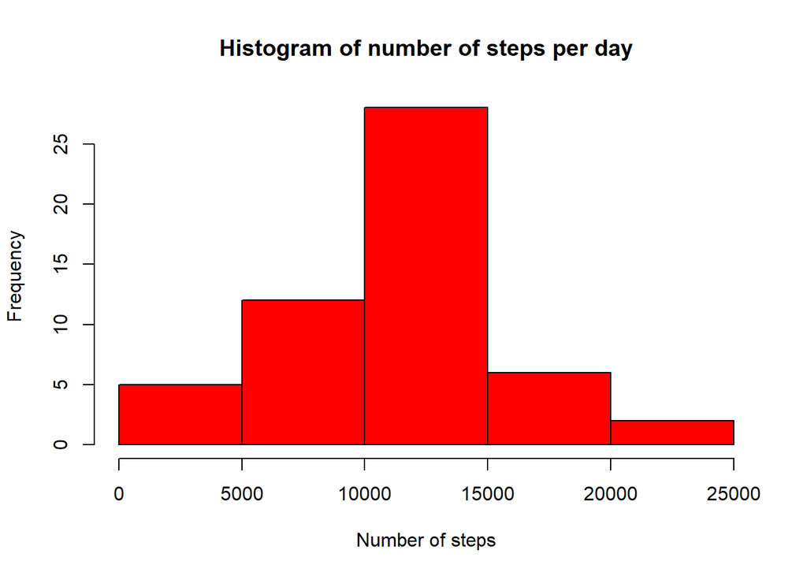

```r
#Taking aggregate of ActivityData according to total number of steps per day
totalsteps <- aggregate(steps ~ date, ActivityData, sum)

#Creating histogram of total number of steps per day
hist(totalsteps$steps, main = "Histogram of number of steps per day", xlab = "Number of steps", col = "red")
```

```r
#Calculating mean of steps
meansteps <- mean(totalsteps$steps)

#Calculating median of steps
mediansteps <- median(totalsteps$steps)
```

[figure not shown]

The mean is 10766.1887 and the median is 10765.

## What is the average daily activity pattern?

- Calculate average steps for each interval for all days.
- Plot the Average Number Steps per Day by Interval.
- Find interval with most average steps.

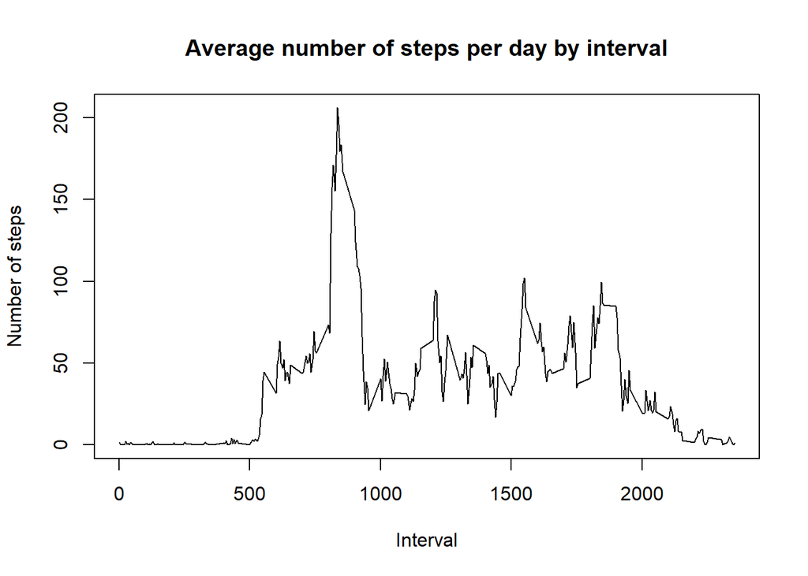

```r
#Aggregating ActivityData according to average number of steps per interval
averagesteps <- aggregate(steps~interval, ActivityData, mean)

#Creating time series plot of average number of steps per day by interval
with(averagesteps, plot(interval, steps, type = "l", xlab = "Interval", ylab = "Number of steps", main = "Average number of steps per day by interval" ))
```

```r
#Finding the interval in which maximum number of steps were taken
maxsteps <- averagesteps[which.max(averagesteps$steps), 1]
```

[figure not shown]

The 5-minute interval, on average across all the days in the data set, containing the maximum number of steps is 835.

## Impute missing values. Compare imputed to non-imputed data.

```r
#Calculating total missing data
sum(is.na(ActivityData))
```

```
## [1] 2304
```

```r
#Creating new data set AvtivityData2 containg imputed values
ActivityData2 <- ActivityData
ActivityData2$steps[is.na(ActivityData2$steps)] <- mean(na.omit(ActivityData$steps))
ActivityData2[as.character(ActivityData2$date) == "2012-10-01", 1] <- 0
```

Recount total steps by day and create Histogram.

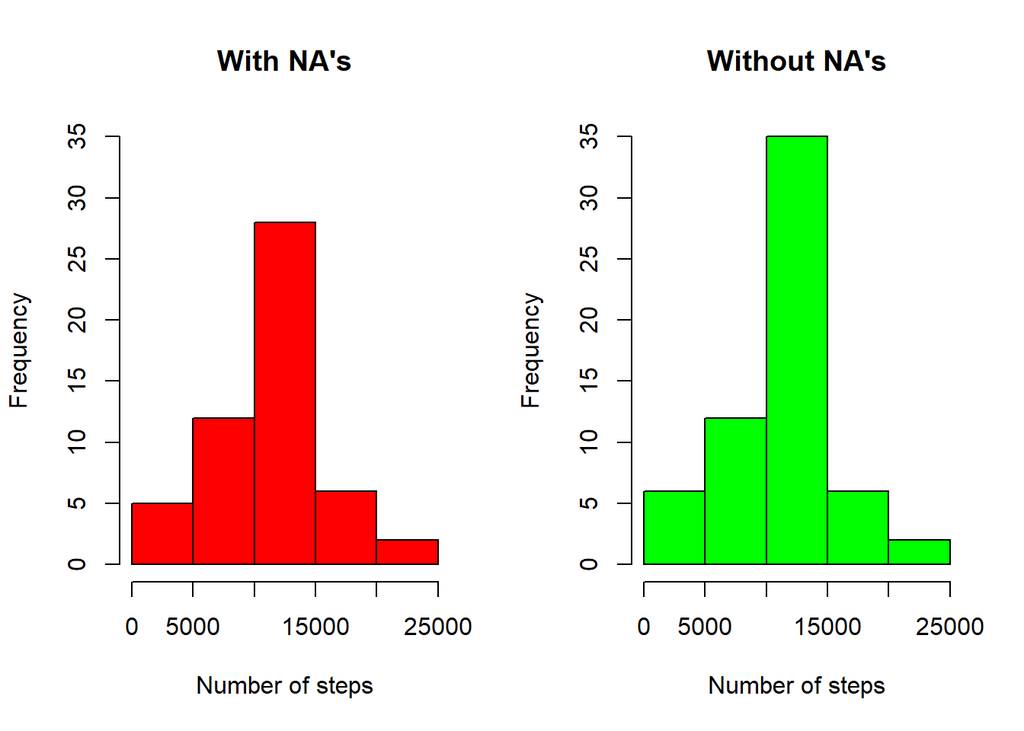

[figure not shown]

```r
#Aggregating ActivityData2 according to total number of steps per day
totalsteps2 <- aggregate(steps ~ date, ActivityData2, sum)

#Creating histograms for number of steps with NA's vs Without NA's
par(mfrow = c(1,2))
hist(totalsteps$steps, main = "With NA's", xlab = "Number of steps", col = "red", ylim = c(0,35))
hist(totalsteps2$steps, main = "Without NA's", xlab = "Number of steps", col = "green")
```

Calculate new mean and median for imputed data.

```r
#Calculating mean value of steps without NA's
meansteps2 <- mean(totalsteps2$steps)

#Calculating median value of steps without NA's
mediansteps2 <- median(totalsteps2$steps)
```

The new mean is 10589.7 and the new median is 10766.1887

Calculate difference between imputed and non-imputed data.

```r
#Calculating difference between mean without NA's vs mean with NA's
meandiff <- meansteps2 - meansteps

#Calculating difference between median without NA's vs mean with NA's
mediandiff <- mediansteps2 - mediansteps
```

The mean difference is -176.5 and the median difference is 1.188

Calculate total difference.

```r
#Calculating difference between total number of steps without NA's vs total number of steps with NA's
totaldiff <- sum(totalsteps2$steps) - sum(totalsteps$steps)
```

The total difference is 75363.32

## Are there differences in activity patterns between weekdays and weekends?

Create a plot to compare and contrast number of steps between the week and weekend.

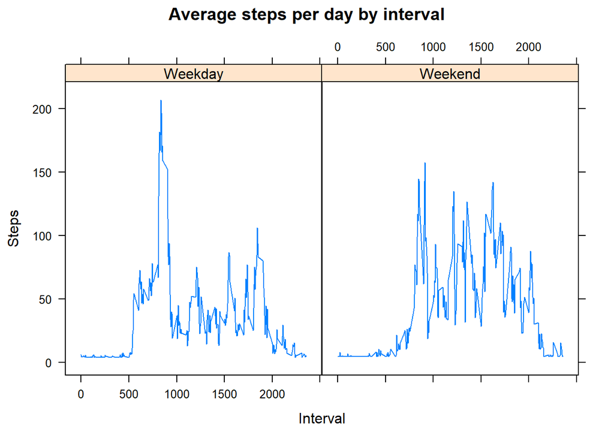

[figure not shown]

```r
#Loading lattice library
library(lattice)

#Creating a vector called weekdays
weekdays <- c("Monday", "Tuesday", "Wednesday", "Thursday",
              "Friday")

#Creating a factor variable daytype which has the levels "weekdays" and "weekends"
ActivityData2$daytype = as.factor(ifelse(is.element(weekdays(as.Date(ActivityData2$date)),weekdays), "Weekday", "Weekend"))

#Aggregating ActivityData2 according to the average number of steps per interval and daytype
averagesteps2 <- aggregate(steps ~ interval + daytype, ActivityData2, mean)


#Creating plot of Average steps per day by interval weekday vs. weekend
xyplot(averagesteps2$steps ~ averagesteps2$interval|averagesteps2$daytype, main = "Average steps per day by interval", xlab = "Interval", ylab = "Steps", type = "l")
```

There is a higher peak earlier on weekdays, and more overall activity on weekends.